# Premiers pas avec shiny… et les packages de visualisation interactive

# Structurer sa page

## sidebarLayout

Le template basique `sidebarLayout` divise la page en deux colonnes et doit contenir :

- `sidebarPanel`, à gauche, en général pour les inputs
- `mainPanel`, à droite, en général pour les outputs

```r
shinyUI(fluidPage(
  titlePanel("Old Faithful Geyser Data"), # title
  sidebarLayout(
    sidebarPanel("SIDEBAR"),
    mainPanel("MAINPANEL")
  )
))
```

[figure not shown]

sdb

## wellPanel

Comme avec le `sidebarPanel` précédent, on peut griser un ensemble d’éléments en utilisant un `wellPanel` :

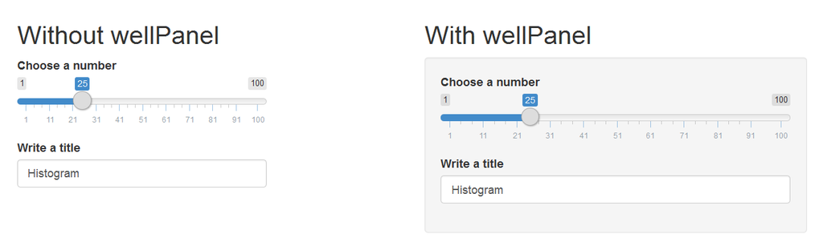

sdb

```r
shinyUI(fluidPage(
  titlePanel("Old Faithful Geyser Data"), # title
  wellPanel(
    sliderInput("num", "Choose a number", value = 25, min = 1, max = 100),
    textInput("title", value = "Histogram", label = "Write a title")
  ),
  plotOutput("hist")
))
```

## navbarPage

Utiliser une barre de navigation et des onglets avec `navbarPage` et `tabPanel`:

```r
shinyUI(
  navbarPage(
    title = "My first app",
    tabPanel(title = "Summary",
             "Here is the summary"),
    tabPanel(title = "Plot",
             "some charts"),
    tabPanel(title = "Table",
             "some tables")
  )
)
```

Nous pouvons rajouter un second niveau de navigation avec un `navbarMenu` :

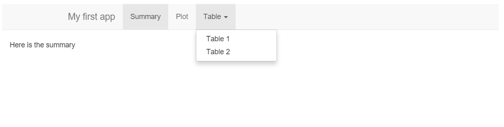

nav

```r
shinyUI(
  navbarPage(
    title = "My first app",
    tabPanel(title = "Summary",
             "Here is the summary"),
    tabPanel(title = "Plot",
             "some charts"),
    navbarMenu("Table",
               tabPanel("Table 1"),
               tabPanel("Table 2")
    )
  )
)
```

## tabsetPanel

Plus généralement, nous pouvons créer des onglets à n’importe quel endroit en utilisant `tabsetPanel` & `tabPanel`:

[figure not shown]

pan

```r
shinyUI(fluidPage(
  titlePanel("Old Faithful Geyser Data"), # title
  sidebarLayout(
    sidebarPanel("SIDEBAR"),
    mainPanel(
      tabsetPanel(
        tabPanel("Plot", plotOutput("plot")),
        tabPanel("Summary", verbatimTextOutput("summary")),
        tabPanel("Table", tableOutput("table"))
      )
    )
  )
))
```

## navlistPanel

Une alternative au `tabsetPanel`, pour une disposition verticale plutôt qu’horizontale : `navlistPanel`

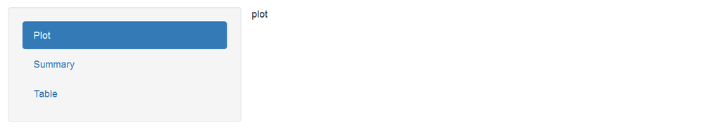

pan

```r
shinyUI(fluidPage(
  navlistPanel(
    tabPanel("Plot", plotOutput("plot")),
    tabPanel("Summary", verbatimTextOutput("summary")),
    tabPanel("Table", tableOutput("table"))
  )
))
```

## Grid Layout

Créer sa propre organisation avec `fluidRow()` et `column()`

- chaque ligne peut être divisée en 12 colonnes
- le dimensionnement final de la page est automatique en fonction des éléments dans les lignes / colonnes

```r
tabPanel(title = "Summary",
         # A fluid row can contain from 0 to 12 columns
         fluidRow(
           # A column is defined necessarily
           # with its argument "width"
           column(width = 4, "column 1"),
           column(width = 4, "column 2"),
           column(width = 4, "column 3"),
         ))
```

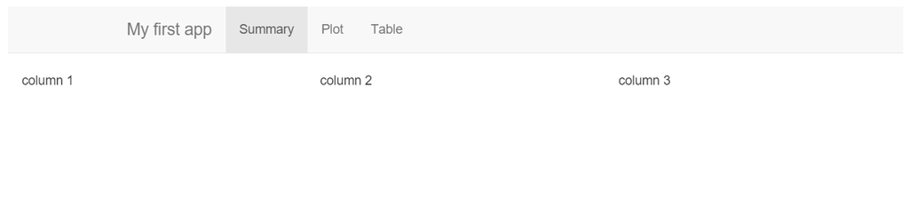

grid

## shinydashboard

Le package [shinydashboard](https://rstudio.github.io/shinydashboard/) propose d’autres fonctions pour créer des tableaux de bords :

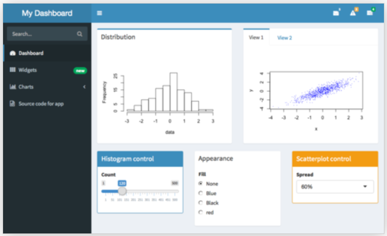

grid

https://rstudio.github.io/shinydashboard/

## Combiner les structures

Toutes les structures peuvent s’utiliser en même temps !

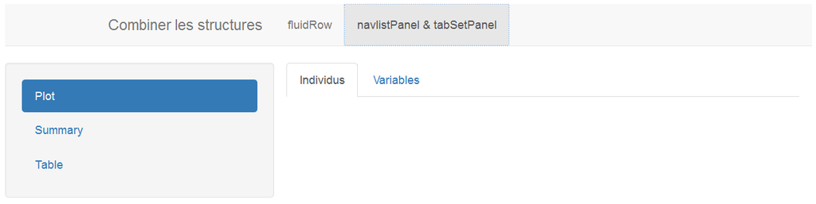

grid

# Graphiques intéractifs

Avec notamment l’arrivée du package [htmlwidgets](http://www.htmlwidgets.org/), de plus en plus de fonctionnalités de librairies javascript sont accessibles sous **R** :

- [dygraphs (time series)](http://rstudio.github.io/dygraphs/)
- [DT (interactive tables)](http://rstudio.github.io/DT/)
- [Leafet (maps)](http://rstudio.github.io/leaflet/)
- d3heatmap
- [threejs (3d scatter & globe)](http://bwlewis.github.io/rthreejs)
- [rAmCharts](http://datastorm-open.github.io/introduction_ramcharts/)
- visNetwork
- …

Plus généralement, jeter un oeil sur la [gallerie suivante!](http://gallery.htmlwidgets.org/)

## Utilisation dans shiny

Tous ces packages sont utilisables simplement dans **shiny**. En effet, ils contiennent les deux fonctions nécessaires :

- **renderXX**
- **xxOutput**

Par exemple avec le package [dygraphs](http://rstudio.github.io/dygraphs/) :

```r
# Server
output$dygraph <- renderDygraph({
  dygraph(predicted(), main = "Predicted Deaths/Month")
})
# Ui
dygraphOutput("dygraph")
```

Ces packages arrivent souvent avec des méthodes permettant d’intéragir avec le graphique, en créant des inputs dans **shiny** afin de déclencher des actions . Par exemple :

- **DT** : création de *input$tableId_rows_selected*, nous informant sur la/les lignes sélectionnée(s)
- **Leaflet** : valeurs du zoom, des clicks, de la latitude/longitude, …
- **visNetwork** : noeuds / groupes sélectionnés, …

Ces points sont (en général) expliqués sur les pages web des différents packages…

De plus, il est également possible d’utiliser de nombreux événements javascripts, et de crééer des nouvelles intéractions avec **shiny** en utilisant *Shiny.onInputChange* :

```r
visNetwork(nodes, edges) %>%
      visEvents(hoverNode = "function(nodes) {
        Shiny.onInputChange('current_node_id', nodes);
      ;}")
```

https://shiny.rstudio.com/articles/js-send-message.html

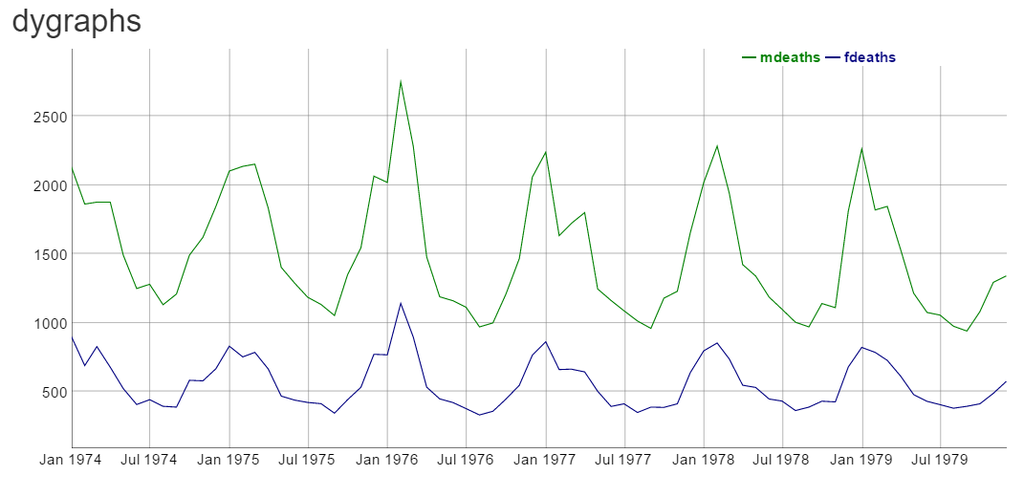

dyg

[figure not shown]

leaf

[figure not shown]

ram

[figure not shown]

vis

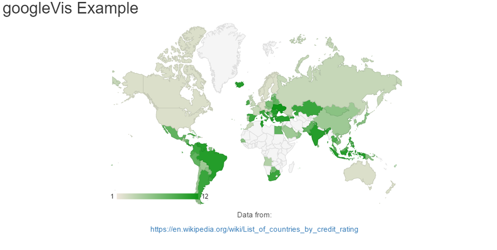

ggv

# Isolation

## Définition

Par défaut, les outputs et les expressions réactives se mettent à jour automatiquement quand un des inputs présents dans le code change de valeur. Dans certains cas, on aimerait pouvoir contrôler un peu cela.

Par exemple, en utilisant un bouton de validation (**actionButton**) des inputs pour déclencher le calcul des sorties.

- un input peut être isolé comme cela `isolate(input$id)`
- une expression avec la notation suivante `isolate({expr})` et l’utilisation de `{}`

## Exemple 1

- **ui.r**: Trois inputs : **color** et **bins** pour l’histogramme, et un **actionButton** :

```r
shinyUI(fluidPage(
  titlePanel("Isolation"),
  sidebarLayout(
    sidebarPanel(
      radioButtons(inputId = "col", label = "Choose a color", inline = TRUE,
                   choices = c("red", "blue", "darkgrey")),
      sliderInput("bins", "Number of bins:", min = 1, max = 50, value = 30),
      actionButton("go_graph", "Update !")
    ),
    mainPanel(plotOutput("distPlot"))
  )
))
```

- **server.r**:

On isole tout le code sauf l’**actionButton** :

```r
shinyServer(function(input, output) {
  output$distPlot <- renderPlot({
    input$go_graph
    isolate({
      inputColor <- input$color
      x <- faithful[, 2]
      bins <- seq(min(x), max(x), length.out = input$bins + 1)
      hist(x, breaks = bins, col = inputColor, border = 'white')
    })
  })
})
```

L’histogramme sera donc mis-à-jour quand l’utilisateur cliquera sur le bouton.

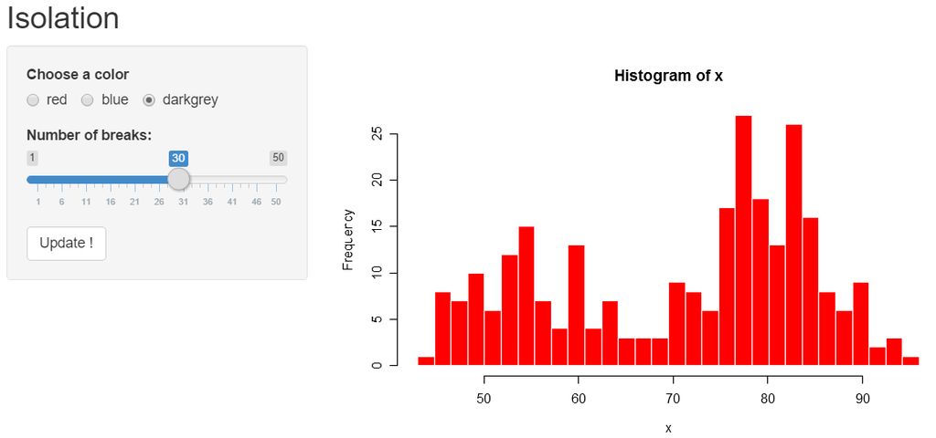

iso

## Exemple 2

- **server.r**:

```r
output$distPlot <- renderPlot({
  input$go_graph
  inputColor <- input$color
  isolate({
    x <- faithful[, 2]
    bins <- seq(min(x), max(x), length.out = input$bins + 1)
    hist(x, breaks = bins, col = inputColor, border = 'white')
  })
})
```

```r
input$go_graph
x <- faithful[, 2]
bins <- seq(min(x), max(x), length.out = isolate(input$bins) + 1)
hist(x, breaks = bins, col = input$color, border = 'white')
```

L’histogramme sera donc mis-à-jour quand l’utilisateur cliquera sur le bouton ou quand la couleur changera.

# Expressions réactives

Les expressions réactives sont très utiles quand on souhaite utiliser le même résultat/objet dans plusieurs outputs, en ne faisant le calcul qu’une fois.

Il suffit pour cela d’utiliser la fonction `reactive` dans le **server.R**

Par exemple, nous voulons afficher deux graphiques à la suite d’une ACP:

- La projection des individus
- La projection des variables

## Exemple sans une expression réactive

- **server.R**: le calcul est réalisé deux fois…

```r
require(FactoMineR) ; data("decathlon")

output$graph_pca_ind <- renderPlot({
  res_pca <- PCA(decathlon[ ,input$variables], graph = FALSE)
  plot.PCA(res_pca, choix = "ind", axes = c(1,2))
})

output$graph_pca_var <- renderPlot({
  res_pca <- PCA(decathlon[,input$variables], graph = FALSE)
  plot.PCA(res_pca, choix = "var", axes = c(1,2))
})
```

## Exemple avec une expression réactive

- **server.R** : Le calcul est maintenant effectué qu’une seule fois !

```r
require(FactoMineR) ; data("decathlon")

res_pca <- reactive({
  PCA(decathlon[,input$variables], graph = FALSE)
})

output$graph_pca_ind <- renderPlot({
  plot.PCA(res_pca(), choix = "ind", axes = c(1,2))
})

output$graph_pca_var <- renderPlot({
  plot.PCA(res_pca(), choix = "var", axes = c(1,2))
})
```

## Note

- Une expression réactive va nous faire gagner du temps et de la mémoire
- **Utiliser des expressions réactives seulement quand cela dépend d’inputs** (pour d’autres variables : http://shiny.rstudio.com/articles/scoping.html)
- **Comme un output** : mis-à-jour chaque fois qu’un input présent dans le code change
- **Comme un input** dans un *renderXX* : l’output est mis-à-jour quand l’expression réactive change
- On récupère sa valeur comme un appel à une fonction, avec des “()”.

## Autres fonctions

Il existe des alternatives à l’utilisation de `reactive` avec `reactiveValues` ou `reactiveVal`.

- `reactiveValues` : initialiser une liste d’objets réactifs
- `reactiveVal` : initialiser un seul objet réactif
- Modification de la valeur des objets avec des `observe` ou des `observeEvent`

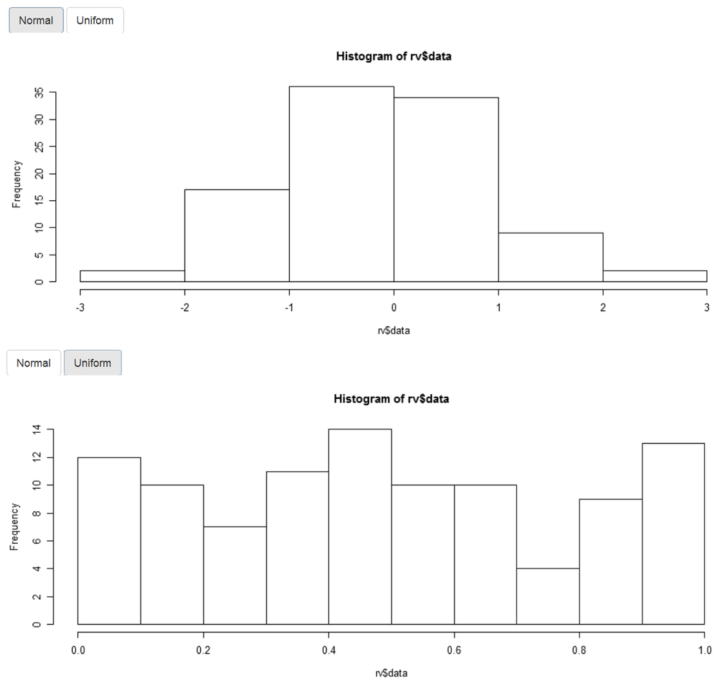

```r
shinyApp(ui = fluidPage(
  actionButton(inputId = "norm", label = "Normal"),
  actionButton(inputId = "unif", label = "Uniform"),
  plotOutput("hist")
),
server = function(input, output) {
  rv <- reactiveValues(data = rnorm(100))
  observeEvent(input$norm, { rv$data <- rnorm(100) })
  observeEvent(input$unif, { rv$data <- runif(100) })
  output$hist <- renderPlot({ hist(rv$data) })
})
```

# Conditional panels

- Il est possible d’afficher conditionnellement ou non certains éléments :

```
conditionalPanel(condition = [...], )
```

- La condition peut se faire sur des inputs ou des outputs
- Elle doit être rédigée en **javascript**…

```
conditionalPanel(condition = "input.checkbox == true", [...])
```

```r
library(shiny)
shinyApp(
  ui = fluidPage(
    fluidRow(
      column(
        width = 4,
        align = "center",
        checkboxInput("checkbox", "View other inputs", value = FALSE)
      ),
      column(
        width = 8,
        align = "center",
        conditionalPanel(
          condition = "input.checkbox == true",
          sliderInput("slider", "Select value", min = 1, max = 10, value = 5),
          textInput("txt", "Enter text", value = "")
        )
      )
    )
  ),
  server = function(input, output) {}
)
```

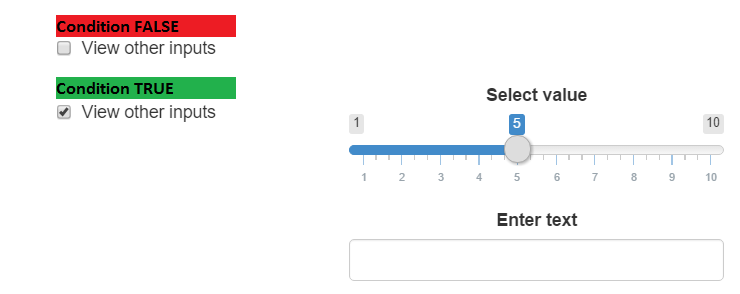

cond1

# Observe & fonctions d’update

## Introduction

- Il existe une série de fonctions pour mettre à jour les inputs et certaines structures
- les fonctions commencent par `update...`
- On les utilise généralement à l’intérieur d’un `observe({expr})`
- La syntaxe est similaire à celle des fonctions de création
- **Attention** : il est nécessaire d’ajouter un argument *“session”* dans la définition du **server**

```r
shinyServer(function(input, output, session) {...})
```

Sur des inputs :

- **updateCheckboxGroupInput**
- **updateCheckboxInput**
- **updateDateInput Change**
- **updateDateRangeInput**
- **updateNumericInput**
- **updateRadioButtons**
- **updateSelectInput**
- **updateSelectizeInput**
- **updateSliderInput**
- **updateTextInput**

Pour changer dynamiquement l’onglet sélectionné :

- **updateNavbarPage**, **updateNavlistPanel**, **updateTabsetPanel**

## Exemple sur un input

```r
shinyUI(fluidPage(
  titlePanel("Observe"),
  sidebarLayout(
    sidebarPanel(
      radioButtons(inputId = "id_dataset", label = "Choose a dataset", inline = TRUE,
                   choices = c("cars", "iris", "quakes"), selected = "cars"),
      selectInput("id_col", "Choose a column", choices = colnames(cars)),
      textOutput(outputId = "txt_obs")
    ),
    mainPanel(fluidRow(
      dataTableOutput(outputId = "dataset_obs")
    ))
  )
))
```

```r
shinyServer(function(input, output, session) {
  dataset <- reactive(get(input$id_dataset, "package:datasets"))

  observe({
    updateSelectInput(session, inputId = "id_col", label = "Choose a column",
                      choices = colnames(dataset()))
  })

  output$txt_obs <- renderText(paste0("Selected column : ", input$id_col))

  output$dataset_obs <- renderDataTable(
    dataset(),
    options = list(pageLength = 5)
  )
})
```

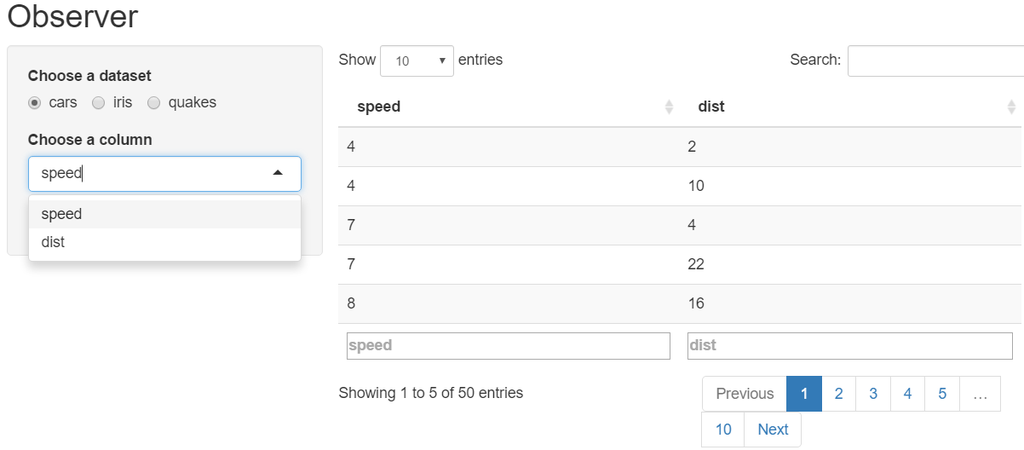

obs1

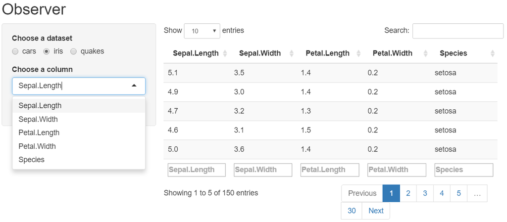

obs2

## Exemple sur des onglets

**Il faut rajouter un id dans la structure**

```r
shinyUI(
  navbarPage(
    id = "idnavbar", # need an id for oberve & update
    title = "A NavBar",
    tabPanel(title = "Summary",
             actionButton("goPlot", "Go to plot !")),
    tabPanel(title = "Plot",
             actionButton("goSummary", "Go to Summary !"))

  )
)
```

```r
shinyServer(function(input, output, session) {
  observe({
    input$goPlot
    updateTabsetPanel(session, "idnavbar", selected = "Plot")
  })
  observe({
    input$goSummary
    updateTabsetPanel(session, "idnavbar", selected = "Summary")
  })
})
```

## observeEvent

- Une variante de la fonction `observe` est disponible avec la fonction `observeEvent`
- On définit alors de façon explicite l’espression qui représente l’événement *et* l’expression qui sera éxécutée quand l’événement se produit

```r
# avec un observe
observe({
  input$goPlot
  updateTabsetPanel(session, "idnavbar", selected = "Plot")
})

# idem avec un observeEvent
observeEvent(input$goSummary, {
  updateTabsetPanel(session, "idnavbar", selected = "Summary")
})
```

# HTML / CSS

## Inclure du HTML

De nombreuses de balises **html** sont disponibles avec les fonctions `tags` :

```r
names(shiny::tags)
```

```
##   [1] "a"           "abbr"        "address"     "area"        "article"
##   [6] "aside"       "audio"       "b"           "base"        "bdi"
##  [11] "bdo"         "blockquote"  "body"        "br"          "button"
##  [16] "canvas"      "caption"     "cite"        "code"        "col"
##  [21] "colgroup"    "command"     "data"        "datalist"    "dd"
##  [26] "del"         "details"     "dfn"         "div"         "dl"
##  [31] "dt"          "em"          "embed"       "eventsource" "fieldset"
##  [36] "figcaption"  "figure"      "footer"      "form"        "h1"
##  [41] "h2"          "h3"          "h4"          "h5"          "h6"
##  [46] "head"        "header"      "hgroup"      "hr"          "html"
##  [51] "i"           "iframe"      "img"         "input"       "ins"
##  [56] "kbd"         "keygen"      "label"       "legend"      "li"
##  [61] "link"        "mark"        "map"         "menu"        "meta"
##  [66] "meter"       "nav"         "noscript"    "object"      "ol"
##  [71] "optgroup"    "option"      "output"      "p"           "param"
##  [76] "pre"         "progress"    "q"           "ruby"        "rp"
##  [81] "rt"          "s"           "samp"        "script"      "section"
##  [86] "select"      "small"       "source"      "span"        "strong"
##  [91] "style"       "sub"         "summary"     "sup"         "table"
##  [96] "tbody"       "td"          "textarea"    "tfoot"       "th"
## [101] "thead"       "time"        "title"       "tr"          "track"
## [106] "u"           "ul"          "var"         "video"       "wbr"
```

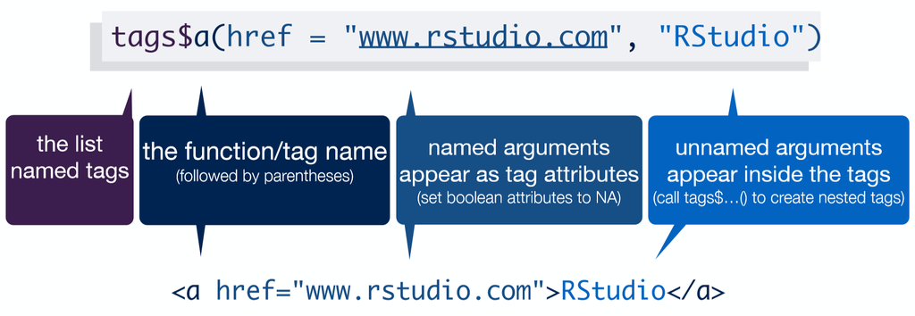

grid

C’est également possible de passer du code **HTML** directement en utilisant la fonction du même nom :

```r
fluidPage(
  HTML("<h1>My Shiny App</h1>")
)
```

## Quelques balises utiles

- `div(..., align = "center")` : centrer les éléments
- `br()` : saut de ligne
- `hr()` : trait horizontal
- `img(src="img/logo.jpg", title="Popup", width = "80%")` : insertion d’une image présente dans **www/img**
- `a(href="https://r2018-rennes.sciencesconf.org/", target="_blank", "Rencontres R")` : lien vers un site
- `a(href = './doc/guide.pdf', target="_blank", class = "btn", icon("download"), 'Télécharger le guide utilisateur')` : lien de téléchargement d’un document présent dans **www/doc**

## CSS : introduction

**Shiny** utilise [Bootstrap](http://getbootstrap.com/) pour la partie **CSS**.

Comme dans du développement web “classique”, nous pouvons modifier le **CSS** de trois façons :

- en faisant un lien vers un fichier .css externe, en ajoutant des feuilles de style dans le répertoire `www`
- en ajoutant du **CSS** dans le header **HTML**
- en écrivant individuellement du CSS aux éléments.

Il y a une notion d’ordre et de priorité sur ces trois informations : le **CSS** “individuel” l’emporte sur le **CSS** du header, qui l’emporte sur le **CSS** externe

On peut aussi utiliser le package shinythemes

## Avec un .css externe

On peut par exemple aller prendre un thème sur [bootswatch](http://bootswatch.com/).

- Deux façons pour le renseigner :
- argument `theme` dans `fluidPage`
- ou avec un tags html : `tags$head` et `tags$link`

```r
library(shiny)
ui <- fluidPage(theme = "mytheme.css",
                # ou avec un tags
                tags$head(
                  tags$link(rel = "stylesheet", type = "text/css", href = "mytheme.css")
                ),
                # reste de l'application
)
```

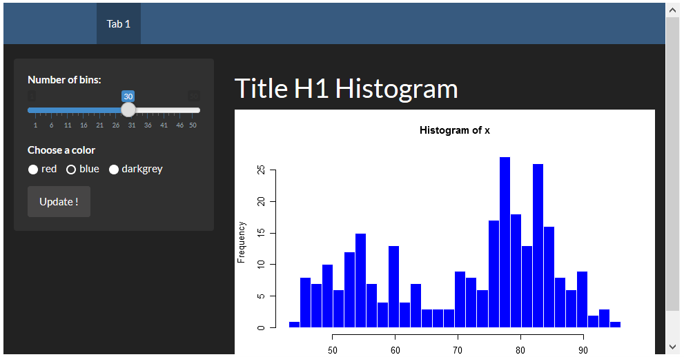

css1

## Ajout de css dans le header

- Le **CSS** inclut dans le header sera prioritaire au **CSS** externe
- inclusion avec les tags html : `tags$head` et `tags$style`

```r
library(shiny)
tags$head(
  tags$style(HTML("h1 { color: #48ca3b;}")
  )
),
# reste de l'application
)
```

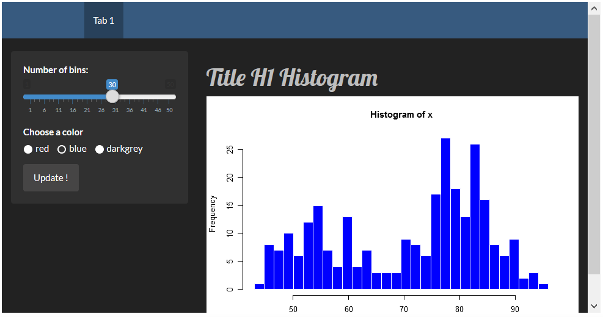

css2

## CSS sur un élément

Pour finir, on peut également passer directement du **CSS** aux éléments **HTML** :

```r
library(shiny)
h1("Mon titre", style = "color: #48ca3b;")
# reste de l'application
)
```

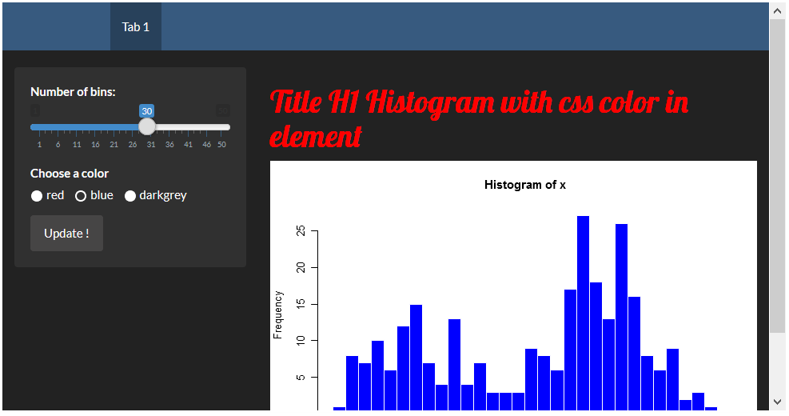

css3

# Quelques bonnes pratiques

- Préférer l’underscore (_) au point (.) comme séparateur dans le nom des variables. En effet, le **.** peut amener de mauvaises intérations avec d’autres langages, comme le **JavaScript**
- Faire bien attention à **l’unicité des différents identifiants** des inputs/outputs
- Pour éviter des problèmes éventuels avec **des versions différentes de packages**, et notamment dans le cas de **plusieurs applications shiny** et/ou différents environnements de travail, essayer d’utiliser [packrat](https://rstudio.github.io/packrat/)
- Mettre toute la **partie “calcul”** dans des **fonctions/un package** et effectuer des tests ([testthat](http://r-pkgs.had.co.nz/tests.html))
- Diviser la partie **ui.R** et **server.R** en plusieurs scripts, un par onglet par exemple :

```r
# ui.R
shinyUI(
  navbarPage("Divide UI & SERVER",
    source("src/ui/01_ui_plot.R", local = TRUE)$value,
    source("src/ui/02_ui_data.R", local = TRUE)$value
  )
)
# server.R
shinyServer(function(input, output, session) {
  source("src/server/01_server_plot.R", local = TRUE)
  source("src/server/02_server_data.R", local = TRUE)
})
```

# Débogage

## Affichage console

- Un des premiers niveaux de débogage est l’utilisation de `print` console au-sein de l’application shiny.
- Cela permet d’afficher des informations lors du développement et/ou de l’éxécution de l’application
- Dans **shiny**, on utilisera de préférence `cat(file=stderr(), ...)` pour être sûr que l’affichage marche dans tous les cas d’outputs, et également dans les logs avec **shiny-server**

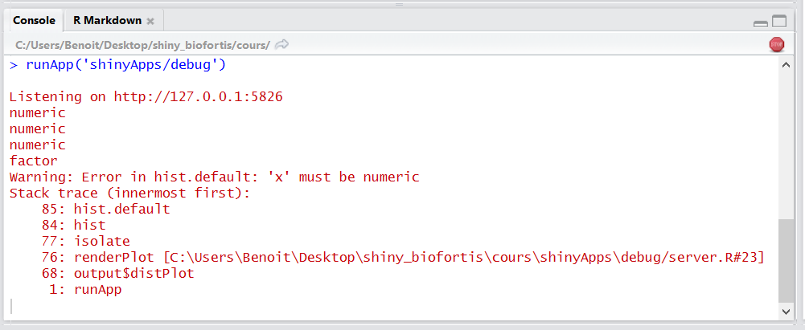

ggv

```r
output$distPlot <- renderPlot({
  x <- iris[, input$variable]
  cat(file=stderr(), class(x)) # affichage de la classe de x
  hist(x)
})
```

## Lancement manuel d’un browser

- On peut insérer le lancement d’un `browser()` à n’importe quel moment
- On pourra alors observer les différents objets et avancer pas-à-pas

```r
output$distPlot <- renderPlot({
  x <- iris[, input$variable]
  browser() # lancement du browser
  hist(x)
})
```

- Ne pas oublier de l’enlever une fois le développement terminé…!

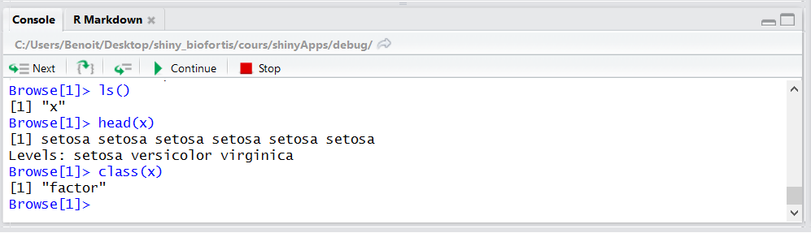

ggv

## Lancement automatique d’un browser

- L’option `options(shiny.error = browser)` permet de lancer un `broswer()` automatiquement lors de l’apparition d’une erreur

```r
options(shiny.error = browser)
```

## Mode “showcase”

- En lançant une application avec l’option `display.mode="showcase"` et l’utilisation de la fonction `runApp()`, on peut observer en direct l’éxécution du code :

```r
runApp("path/to/myapp", display.mode="showcase")
```

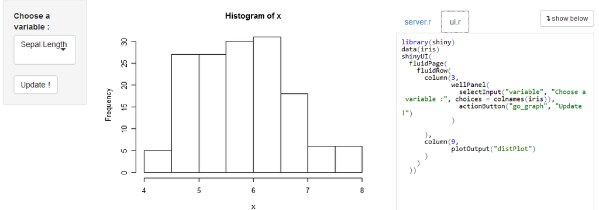

ggv

## Reactive log

- En activant l’option `shiny.reactlog`, on peut visualiser à tous instants les dépendances et les flux entre les objets réactifs de **shiny**
- soit en tappant `ctrl+F3` dans le navigateur web
- soit en insérant `showReactLog()` au-sein du code shiny

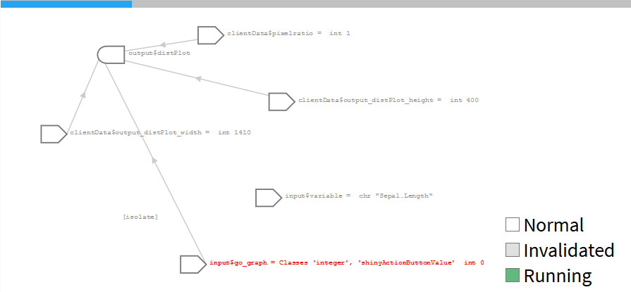

ggv

```r
options(shiny.reactlog=TRUE)

output$distPlot <- renderPlot({
  x <- iris[, input$variable]
  showReactLog() # launch shiny.reactlog
  hist(x)
})
```

## Communication client/server

- Toutes les communications entre le client et le server sont visibles en utilisant l’option `shiny.trace`

```r
options(shiny.trace = TRUE)
```

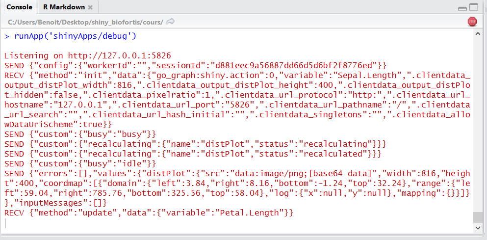

ggv

## Traçage des erreurs

- Depuis `shiny_0.13.1`, on récupère la stack trace quand une erreur se produit
- Si besoin, on peut récupérer une stack trace encore plus complète, comprenant les diffénrets fonctions internes, avec `options(shiny.fullstacktrace = TRUE)`

```r
options(shiny.fullstacktrace = TRUE)
```

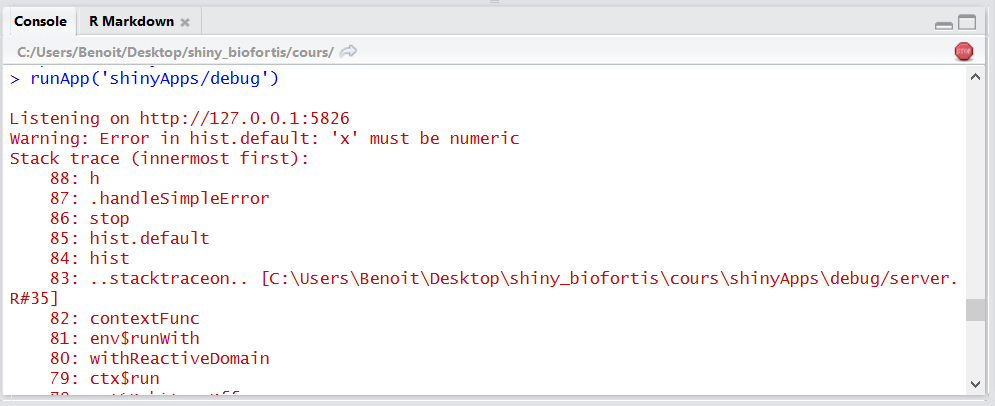

ggv

## Références / Tutoriaux / Exemples

- http://shiny.rstudio.com/
- http://shiny.rstudio.com/articles/
- http://shiny.rstudio.com/tutorial/
- http://shiny.rstudio.com/gallery/
- https://www.rstudio.com/products/shiny/shiny-user-showcase/
- http://www.showmeshiny.com/